# Estimación puntual y valuación de derivados

Módulo 2

David R. Montalván Hernández

# **Estimación puntual**

## **Muestra**

Una muestra, $\mathbf{X}$, es una colección de observaciones $X_1, \ldots, X_n$ que son **independientes e idénticamente distribuidas**, es decir, cada $X_i$ tiene la misma densidad $f$.

Esta densidad $f$ está parametrizada por un vector $\mathbf{\theta} = (\theta_1, \ldots, \theta_m)$. Desde el punto de vista **frecuentista** este vector es **desconocido pero fijo**.

Nuestro objetivo es estimar $\mathbf{\theta}$ utilizando la información de la muestra.

## **Estimador y estimados**

Un **estimador** para un parámetro $\mathbf{\theta}$ es una función, $T$, que involucra únicamente las observaciones de una muestra $X_1, \ldots, X_n$. Un estimador es una variable aleatoria $T(X_1, \ldots, X_n)$.

Una vez observados los valores de la muestra, $\mathbf{X} = \mathbf{x}$, el valor $t = T(\mathbf{x})$ es llamado un **estimado** de $\mathbf{\theta}$, este estimado es un número.

## **Función de verosimilitud (likelihood)**

Si $X_1 = x_1, \ldots, X_n = x_n$ forman una muestra y $f(x; \mathbf{\theta})$ es la densidad de cada $X_i$; la función de verosimilitud está dada por:

$$L(\mathbf{\theta}) = \Pi_{i=1}^{n} f(x_i; \mathbf{\theta})$$

Por el supuesto de independencia, la función de verosimilitud, es la función de densidad conjunta de la muestra pero vista como función del parámetro $\theta$.

## **Estimador máximo verosímil**

Un **estimado** máximo verosímil de $\theta$ es un valor $\widehat{\theta}(\mathbf{x})$ que maximiza la función de verosimilitud.

$$L(\widehat{\theta}) = \max_{\theta} L(\theta)$$

Un **estimador** máximo verosimil de $\theta$ es $\widehat{\theta}(X)$, es decir, es una variable aleatoria.

## **Log-verosimilitud (log-likelihood)**

Debido a que $L(\mathbf{\theta})$ es un producto de funciones, resulta más conveniente optimizar la **log-verosimilitud**, la cual está dada por:

$$Ln(L(\mathbf{\theta})) = \sum_{i=1}^{n} Ln(f(x_i; \mathbf{\theta}))$$

## **Receta para obtener estimadores máximos verosímiles**

1. Encuentre la función de verosimilitud.
2. Encuentre la función de log-verosimilitud.
3. Derive la log-verosimilitud respecto a $\theta$ (obtenga el gradiente si $\theta$ es un vector).
4. Encuentre los puntos críticos, es decir, aquellos valores de $\theta$ tales que $\nabla Ln(L(\theta)) = 0$.
5. Aplique criterios de segunda derivada para saber que puntos críticos corresponden a puntos máximos.

## **Ejercicio**

Suponga que se tiene una muestra de variables que provienen de una distribución Bernoulli, $Ber(p)$, en donde $p$ es un parámetro desconocido.

$$f(x;p) = p^{x}(1 - p)^{1 - x}$$

Encuentre el estimador máximo verosímil de $p$.

## **Ejercicio**

Suponga que se tiene una muestra de variables que provienen de una distribución normal, $N(\mu, \sigma^2)$, en donde $\mu$ es un parámetro desconocido pero sabemos quien es $\sigma^2$.

$$f(x;\mu,\sigma^2) = \dfrac{1}{\sigma \sqrt{2 \pi}} exp\left[-\dfrac{(x - \mu)^2}{2 \sigma^2}\right]$$

Encuentre el estimador máximo verosímil de $\mu$.

## **Ejercicio**

Suponga que se tiene una muestra de variables que provienen de una distribución Poisson, $Poi(\lambda)$, en donde $\lambda$ es un parámetro desconocido.

$$f(x; \lambda) = \dfrac{\lambda^{x} e^{-\lambda}}{x!}$$

Encuentre el estimador máximo verosímil de $\lambda$.

## **Invarianza de los MLE**

Si $\widehat{\theta}$ es un estimador máximo verosímil de $\theta$ y $g$ es una función de $\theta$, entonces $g(\widehat{\theta})$ es un estimador máximo verosímil de $g(\theta)$.

## **Estimadores insesgados**

Un estimador $T$ para el parámetro $\tau(\theta)$, se llama un estimador insesgado (unbiased) si y sólo si

$$E[T] = \tau(\theta)$$

para todo $\theta$.

El sesgo (bias) de un estimador, $T$, para un parámetro $\tau(\theta)$, está dado por $E[T] - \tau(\theta)$.

## **Error cuadrático medio**

Si $T$ es un estimador de $\tau(\theta)$, el error cuadrático medio de $T$ ($MSE_{T}$) está dado por

$$E\left[(T - \tau(\theta))^2 \right] = Var(T) + \left[E(T) - \tau(\theta)\right]^2$$

## **Scipy optimize**

Para resolver problemas de optimización (**minimización**), podemos utilizar el módulo **optimize** de la librería **scipy**

https://docs.scipy.org/doc/scipy/reference/tutorial/optimize.html

```python
from scipy.optimize import minimize
from scipy.optimize import Bounds
```

## **Ejercicio**

Revise el archivo `Ejercicios_MLE_Valuacion.ipynb`

# **Derivados financieros**

## **Instrumento derivado**

Un instrumento derivado es un contrato entre dos o más partes y cuyo valor se deriva a partir del valor de un activo subyacente.

## **Opciones sobre acciones**

Una opción nos da el **derecho** de comprar (opción call) o vender (opción put) a un precio determinado (el precio strike) una unidad de la acción a la cual está referenciada.

## **Opción europea**

Una opción **europea** es una opción que se puede ejercer únicamente en una fecha determinada.

## **Opción americana**

Una opción **americana** es una opción que se puede ejercer en cualquier fecha dentro de un periodo de tiempo determinado.

## **Payoff de opciones europeas**

Sea $T$ el momento en que se establece que la opción se puede ejecutar y sea $K$ el precio strike. El payoff de una opción call europea con subyacente $S$, está dado por:

$$Call_{T}(S,K) = \max(S_T - K, 0)$$

Por otra parte, el payoff de una opción put europea es

$$Put_{T}(S,K) = \max(K - S_T, 0)$$

Un call es una apuesta a una tendencia a la alza en los precios, mientras que un put es una apuesta a una tendencia a la baja.

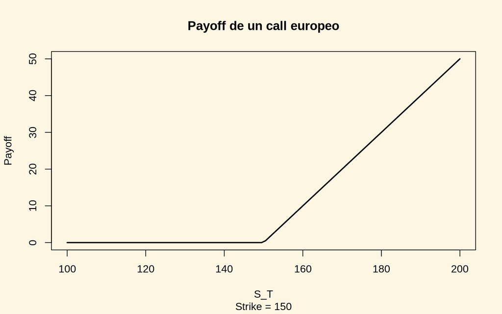

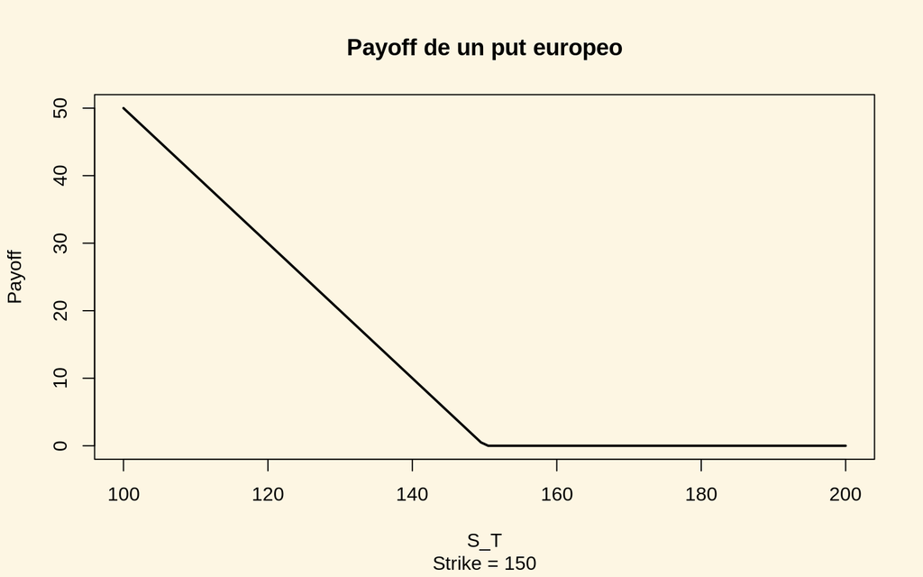

## **Movimiento browniano**

Un movimiento browniano (formalmente un proceso de Wiener) es un proceso estocástico $\{W\}_{t\geq 0}$ que satisface lo siguiente:

1. $W_0 = 0$.
2. El mapeo $t \rightarrow W_t$ es una función continua.
3. Los incrementos $\{W_{t_1} - W_{t_0}, W_{t_2} - W_{t_1}, \ldots, W_{t_k} - W_{t_{k-1}} \}$ son variables aleatorias independientes.
4. Para $s < t$, $W_t - W_s \sim N(0, \sigma^2 = t - s)$.

## **Modelo Black-Scholes-Merton**

En el modelo de Black-Scholes-Merton, se tiene un mercado en el cual existen únicamente tres instrumentos:

1. Acción $S$.
2. Cuenta de ahorro, $B_t$ que gana una tasa libre de riesgo $r$.

$$\dfrac{B_t}{B_t} = rdt \implies B_t = e^{rt}$$
3. Instrumento derivado $V$ cuyo subyacente es $S$.

El precio de la acción se modela utilizando un movimiento browniano geométrico

$$dS_t = rS_tdt + \sigma S_tdW_t$$

**Nota:**

Realmente esta es la dinámica que sigue $\{S_t\}_{t\geq 0}$ bajo una medidad de probabilidad, $\mathbb{Q}$, llamada medida neutral al riesgo.

## **Valuación de derivados**

Bajo ciertas condiciones, el precio en el tiempo $t$ de un producto financiero derivado con función de payoff $H$ y cuyo subyacente es $S$ está dado por:

$$Precio_H(S,t) = e^{-r(T-t)}E_{Q}[H(S,T)]$$

en donde $Q$ es la medida neutral al riesgo.

En particular para un call europeo

$$Call(S,K,t,T,r,\sigma) = e^{-r(T-t)}E_{Q}[\max(S_T - K, 0)]$$

## **Monte Carlo para valuar derivados**

1. Simula trayectorias del subyacente.
2. Para cada trayectoria calcula el payoff del derivado $H(S,T)$.
3. Aproxima $E_{Q}[H(S,T)]$ promediando el payoff de cada una de las trayectorias.
4. Aplica el factor de descuento apropiado, en este caso $e^{-r(T-t)}$, a la cantidad obtenida en el punto anterior.

## **Esquema de Euler para simular $S_t$**

Para simular el proceso dado por la ecuación diferencial estocástica

$$dS_t = rS_tdt + \sigma S_t dW_t$$

1. Crear una partición, $\Pi = \{t_0 = 0, t_1, \ldots, t_N = T \}$ del intervalo $[0, T]$ dividiéndolo en $N$ partes iguales (número de pasos) y haciendo $\delta = \dfrac{T - t_0}{N}$
2. Sustituir $dt$ por $\delta$ y $dW_t$ por $\sqrt{\delta}Z$ en donde $Z \sim N(0,1)$.
3. Calcular los siguientes precios utilizando la discretización

$$S_{t_{i+1}} = S_{t_{i}} + r S_{t_{i}} \delta + \sigma S_{t_{i}}\sqrt{\delta}Z_{i+1}$$

## **Fórmulas analíticas**

Bajo el modelo de Black-Scholes, el precio, en el tiempo $t$, de un call del tipo europeo está dado por

$$Call(S,K,t,T,r,\sigma) = S_t\mathbf{N}(d_1) - e^{-r(T-t)}K\mathbf{N}(d_2)$$

- $\mathbf{N}$ Es la **función de distribución acumulada** de una variable aleatoria $N(0,1)$.
- $d_1 = \dfrac{ \ln \dfrac{S_t}{K} + (r + 0.5\sigma^2) (T-t) }{\sigma \sqrt{T-t}}$
- $d_2 = \dfrac{ \ln \dfrac{S_t}{K} + (r - 0.5\sigma^2) (T-t) }{\sigma \sqrt{T-t}}$
- $T$ es la fecha de vencimiento (generalmente en años).
- $t$ es la fecha de valuación.
- $r$ es la tasa libre de riesgo
- $\sigma$ volatilidad del subyacente
- $K$ precio strike.

En el caso de un put, se tiene

$$Put(S,K,t,T,r,\sigma) = e^{-r(T-t)}K\mathbf{N}(-d_2) - S_t\mathbf{N}(-d_1)$$